# An Introduction to corrplot Package

## Visualize non-correlation matrix, NA value and math label

We can visualize a non-correlation matrix by set `is.corr=FALSE`, and assign colors by `col.lim`. If the matrix have both positive and negative values, the matrix transformation keep every values positiveness and negativeness.

If your matrix is rectangular, you can adjust the aspect ratio with the `win.asp` parameter to make the matrix rendered as a square.

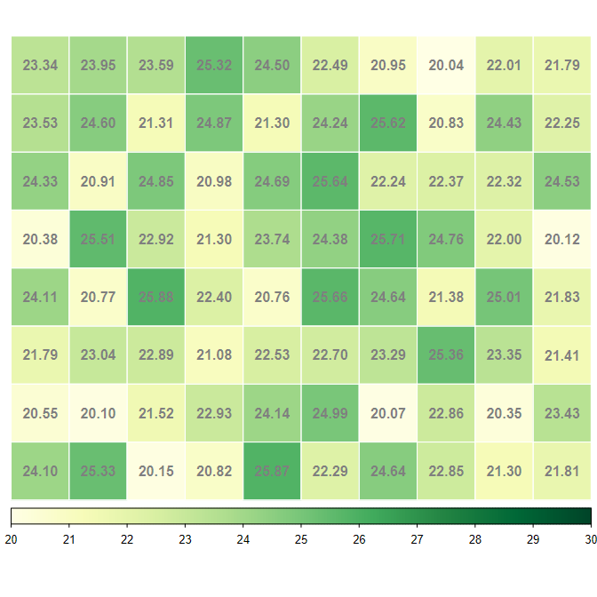

```r
## matrix in [20, 26], grid.col
N1 = matrix(runif(80, 20, 26), 8)
corrplot(N1, is.corr = FALSE, col.lim = c(20, 30), method = 'color', tl.pos = 'n',
         col = COL1('YlGn'), cl.pos = 'b', addgrid.col = 'white', addCoef.col = 'grey50')
```

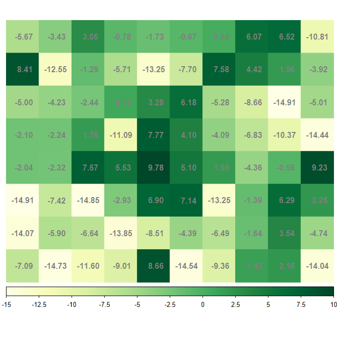

```r
## matrix in [-15, 10]
N2 = matrix(runif(80, -15, 10), 8)

## using sequential colors, transKeepSign = FALSE
corrplot(N2, is.corr = FALSE, transKeepSign = FALSE, method = 'color', col.lim = c(-15, 10),
         tl.pos = 'n', col = COL1('YlGn'), cl.pos = 'b', addCoef.col = 'grey50')
```

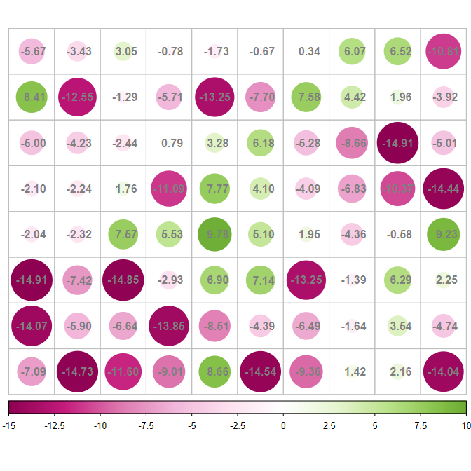

```r
## using diverging colors, transKeepSign = TRUE (default)
corrplot(N2, is.corr = FALSE, col.lim = c(-15, 10),
         tl.pos = 'n', col = COL2('PiYG'), cl.pos = 'b', addCoef.col = 'grey50')
```

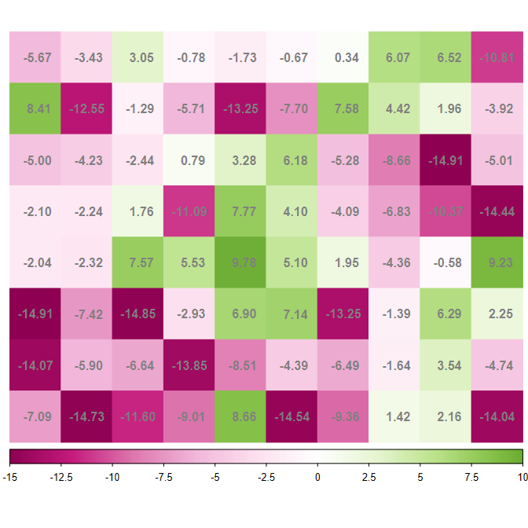

```r
## using diverging colors
corrplot(N2, is.corr = FALSE, method = 'color', col.lim = c(-15, 10), tl.pos = 'n',
         col = COL2('PiYG'), cl.pos = 'b', addCoef.col = 'grey50')
```

Notice: when `is.corr` is `TRUE`, `col.lim` only affect the color legend If you change it, the color on correlation matrix plot is still assigned on `c(-1, 1)`

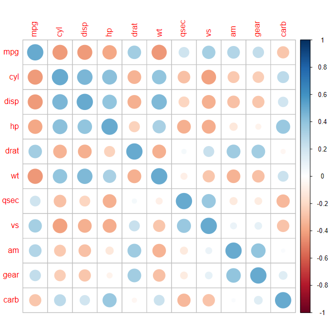

```r
# when is.corr=TRUE, col.lim only affect the color legend display
corrplot(M/2)
```

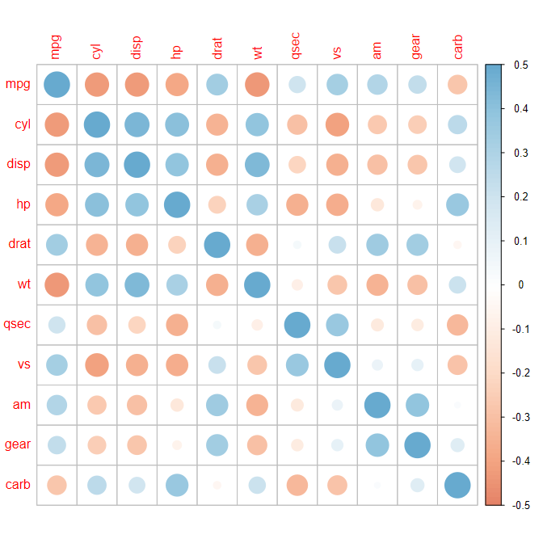

```r
corrplot(M/2, col.lim=c(-0.5, 0.5))
```

By default, **corrplot** renders NA values as `'?'` characters. Using `na.label` parameter, it is possible to use a different value (max. two characters are supported).

Since version `0.78`, it is possible to use plotmath expression in variable names. To activate plotmath rendering, prefix your label with `'$'`.

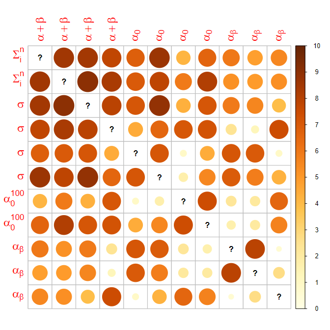

```r
M2 = M
diag(M2) = NA
colnames(M2) = rep(c('$alpha+beta', '$alpha[0]', '$alpha[beta]'),
                   c(4, 4, 3))
rownames(M2) = rep(c('$Sigma[i]^n', '$sigma',  '$alpha[0]^100', '$alpha[beta]'),
                   c(2, 4, 2, 3))
corrplot(10*abs(M2), is.corr = FALSE, col.lim = c(0, 10), tl.cex = 1.5)
```

## Visualize p-value and confidence interval

`corrplot()` can also visualize p-value and confidence interval on the correlation matrix plot. Here are some important parameters.

About p-value:

- `p.mat` is the p-value matrix, if `NULL`, parameter `sig.level`, `insig, pch`, `pch.col`, `pch.cex` are invalid.
- `sig.level` is significant level, with default value 0.05. If the p-value in `p-mat` is bigger than `sig.level`, then the corresponding correlation coefficient is regarded as insignificant. If `insig` is `'label_sig'`, `sig.level` can be an increasing vector of significance levels, in which case `pch` will be used once for the highest p-value interval and multiple times (e.g. `'*'`, `'**'`, `'***'`) for each lower p-value interval.
- `insig` Character, specialized insignificant correlation coefficients, `'pch'` (default), `'p-value'`, `'blank',` `'n'`, or `'label_sig'`. If `'blank'`, wipe away the corresponding glyphs; if `'p-value'`, add p-values the corresponding glyphs; if `'pch'`, add characters (see pch for details) on corresponding glyphs; if `'n'`, don’t take any measures; if `'label_sig'`, mark significant correlations with `pch` (see `sig.level`).
- `pch` is for adding character on the glyphs of insignificant correlation coefficients (only valid when insig is `'pch'`). See `?par` .

About confidence interval:

- `plotCI` is character for the method of plotting confidence interval. If `'n'`, don’t plot confidence interval. If `'rect'`, plot rectangles whose upper side means upper bound and lower side means lower bound respectively.
- `lowCI.mat` is the matrix of the lower bound of confidence interval.
- `uppCI.mat` is the Matrix of the upper bound of confidence interval.

We can get p-value matrix and confidence intervals matrix by `cor.mtest()` which returns a list containing:

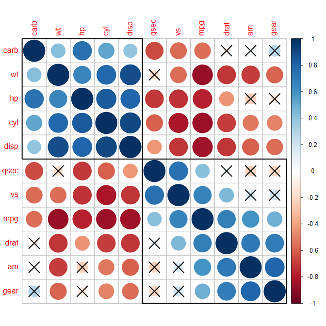

```r
testRes = cor.mtest(mtcars, conf.level = 0.95)

## specialized the insignificant value according to the significant level
corrplot(M, p.mat = testRes$p, sig.level = 0.10, order = 'hclust', addrect = 2)
```

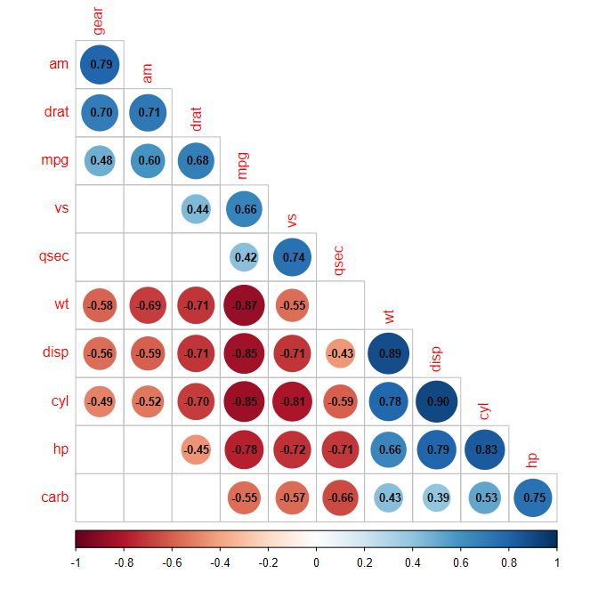

```r
## leave blank on non-significant coefficient
## add significant correlation coefficients
corrplot(M, p.mat = testRes$p, method = 'circle', type = 'lower', insig='blank',
         addCoef.col ='black', number.cex = 0.8, order = 'AOE', diag=FALSE)
```

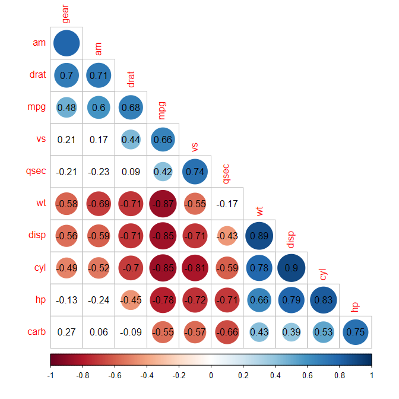

```r
## leave blank on non-significant coefficient
## add all correlation coefficients
corrplot(M, p.mat = testRes$p, method = 'circle', type = 'lower', insig='blank',
         order = 'AOE', diag = FALSE)$corrPos -> p1
text(p1$x, p1$y, round(p1$corr, 2))
```

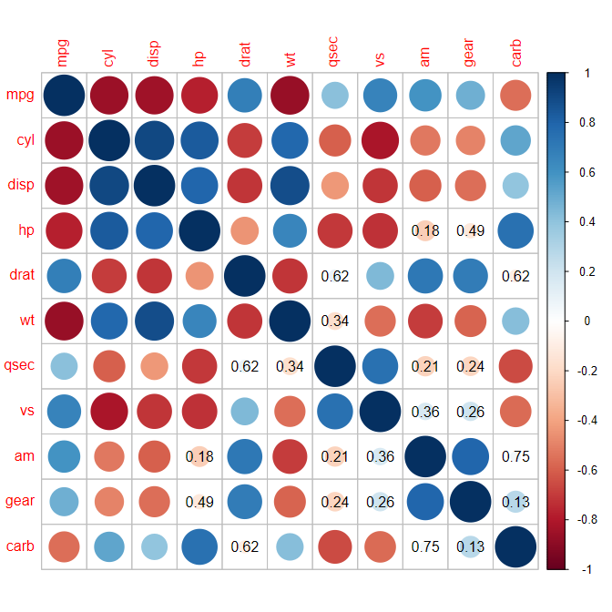

```r
## add p-values on no significant coefficients
corrplot(M, p.mat = testRes$p, insig = 'p-value')
```